# Final_Model

Arm and Guy

May 14, 2021

```r
urlfile="https://raw.githubusercontent.com/gthampak/Arm_Guy_MATH150_Project/main/HELPdata.csv"

HELPdata <- read_csv(url(urlfile))
```

###Treatment Variable

`group` Randomization Group (0=Control, 1=Clinic)

###Variables associated with pain

`b7` Amount of bodily pain – past 4 weeks (1=None, 2=Very mild, 3= Mild, 4=Moderate, 5= Severe, 6= Very severe)

`b8` Amount of pain interfering with normal work-last 4 weeks (1=Not at all, 2=A little bit, 3=Moderately, 4=Quite a bit, 5=Extremely)

`bp` SF-36 pain index (0-100)

`c2h1` Ever had abdom pain req overnt hosp stay (0=No, 1=Yes)

`c2h2` Abdom pain req ovrnt hosp stay-last 6 months (0=No, 1=Yes)

`c2m1` Chest pain using cocaine req ER/hosp (0=No, 1=Yes)

`c2m2` Chest pain using coc req ER/hosp-last 6 months (0=No, 1=Yes)

`c2o1` Lower back pain > 3 months req med attn (0=No, 1=Yes)

`c2o2` Lwr back pain >3 months req med attention-last 6 months (0=No, 1=Yes)

`rawbp` Raw SF-36 pain index

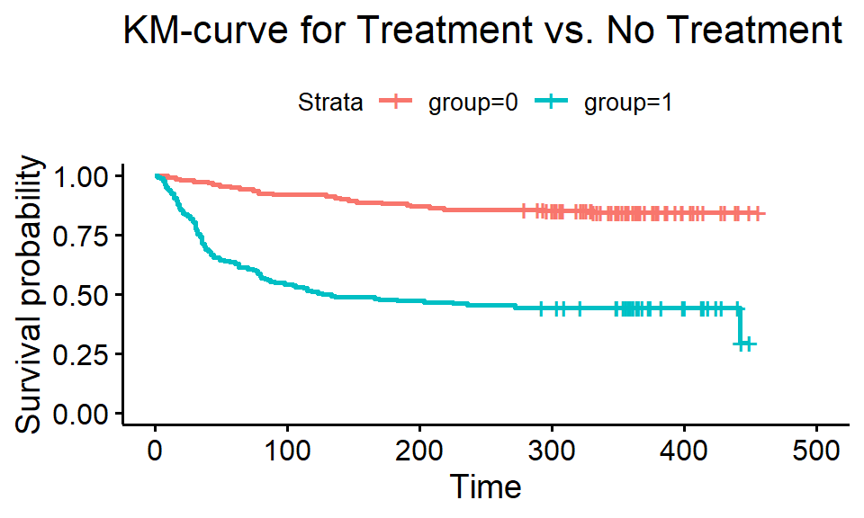

```r
HELPdata_survfit <- survfit(Surv(dayslink, linkstatus) ~ group, data=HELPdata)

ggsurvplot(HELPdata_survfit, conf.type = "TRUE") +
  ggtitle("KM-curve for Treatment vs. No Treatment")
```

```r
coxph(Surv(dayslink, linkstatus) ~ group, data=HELPdata) %>% tidy()
```

| term | estimate | std.error | statistic | p.value |
| --- | --- | --- | --- | --- |
| group | 1.641519 | 0.2236544 | 7.339533 | 2.143397e-13 |

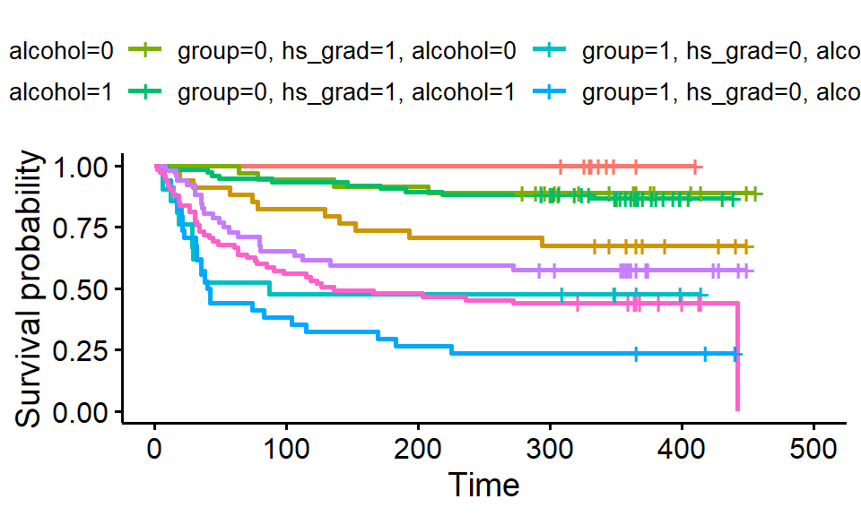

```r
HELPdata_survfit <- survfit(Surv(dayslink, linkstatus) ~ group + hs_grad + alcohol, data=HELPdata)

ggsurvplot(HELPdata_survfit, conf.type = "TRUE")
```

```r
coxph(Surv(dayslink, linkstatus) ~ group + hs_grad + alcohol, data=HELPdata) %>% tidy()
```

| term | estimate | std.error | statistic | p.value |
| --- | --- | --- | --- | --- |
| group | 1.7203423 | 0.2248648 | 7.650561 | 2.001039e-14 |
| hs_grad | -0.5517653 | 0.1838217 | -3.001632 | 2.685362e-03 |
| alcohol | 0.5449570 | 0.1961456 | 2.778329 | 5.463930e-03 |

```r
coxph(Surv(dayslink, linkstatus) ~ group + a9, data=HELPdata) %>% tidy()
```

| term | estimate | std.error | statistic | p.value |
| --- | --- | --- | --- | --- |
| group | 1.6782563 | 0.22479735 | 7.465641 | 8.289507e-14 |
| a9 | -0.1212052 | 0.04841285 | -2.503575 | 1.229455e-02 |

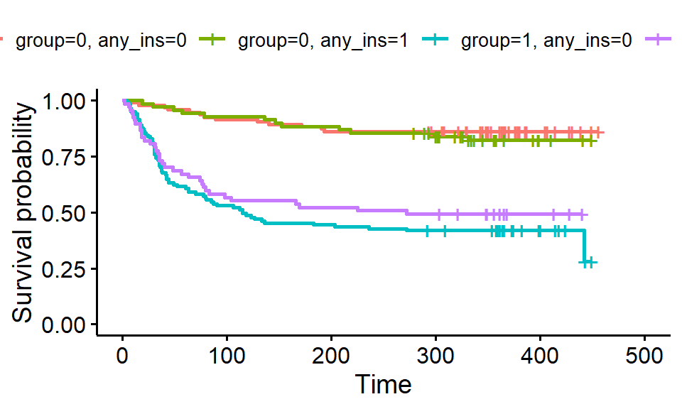

```r
HELPdata_survfit <- survfit(Surv(dayslink, linkstatus) ~ group + any_ins, data=HELPdata)

ggsurvplot(HELPdata_survfit, conf.type = "TRUE")
```

```r
coxph(Surv(dayslink, linkstatus) ~ group, data=HELPdata) %>% tidy()
```

| term | estimate | std.error | statistic | p.value |
| --- | --- | --- | --- | --- |
| group | 1.641519 | 0.2236544 | 7.339533 | 2.143397e-13 |

[figure not shown]

```r
HELPdata_survfit <- survfit(Surv(dayslink, linkstatus) ~ group + gh, data=HELPdata)

ggsurvplot(HELPdata_survfit, conf.type = "TRUE")
```

```r
coxph(Surv(dayslink, linkstatus) ~ group + gh, data=HELPdata) %>% tidy()
```

| term | estimate | std.error | statistic | p.value |
| --- | --- | --- | --- | --- |
| group | 1.636384647 | 0.223766190 | 7.3129218 | 2.613951e-13 |
| gh | -0.002736678 | 0.003460167 | -0.7909092 | 4.289970e-01 |

###Final

Variables

ANY_UTIL Any recent health utilization (0=No, 1=Yes)a CES_D CES-D score, measure of depressive symptoms, high scores are worse CNTRL InDUC-2L-Control score C_AU ASI-Composite score for alcohol use C_DU ASI-Composite score for drug use C_MS ASI-Composite medical status

D5_REC Medical trtmt is important y/n (0=No, 1=Yes) D5 How import is trtmnt for these med probs (0=Not at all, 1=Slightly, 2= Moderately, 3= Considerably, 4= Extremely E10A have you been to med clinic-last 6 months (0=No, 1=Yes) E15C2 I did not know where to go for help (0=No, 1=Yes) E8A1 Saw MD/H care worker regarding alcohol/drugs-last 6 months (0=No, 1=Yes) FRML_SAT Formal substance abuse treatment y/n (0=No, 1=Yes)

GH SF-36 general health perceptions (0-100) HT Raw SF-36 health transition item MH SF-36 mental health index (0-100) PF SF-36 physical functioning (0-100) RE SF-36 role-emotional (0-100) RP SF-36 role physical (0-100)

H14 According to interviewer, which substance is main problem (0=No problem, 1=Alcohol, 2=Alcohol to intox, 3=Heroin 4=Methadone, 5=Other opiate/analg, 6=Barbituates, 7=Sed/hyp/tranq, 8=Cocaine, 9=Amphetamines, 10=Marij/cannabis, 15=Alcohol and one or more drug, 16=More than one drug) PRIM_SUB First drug of choice (0=None, 1=Alcohol, 2=Cocaine, 3=Heroin, 4=Barbituates, 5=Benzos, 6=Marijuana, 7=Methadone, 8=Opiates)

H19A How import is treatment for alcohol problems now (0=Not at all, 1=Slightly, 2=Moderately, 3=Considerably, 4=Extremely) H19B How important is trtmnt for drug probs now (0=Not at all, 1=Slightly, 2=Moderately, 3=Considerably, 4=Extremely)

```r
coxph(Surv(dayslink, linkstatus) ~ group + any_util + ces_d + cntrl + c_au + c_du + c_ms + gh + ht + mh + pf + re + rp + h14 + prim_sub + h19a + h19b + s1a + s1b + s1c, data=HELPdata) %>% tidy()
```

| term | estimate | std.error | statistic | p.value |
| --- | --- | --- | --- | --- |
| group | 1.7309246742 | 0.232411374 | 7.447676267 | 9.499858e-14 |
| any_util | -0.5761979860 | 0.219151280 | -2.629224823 | 8.557976e-03 |
| ces_d | 0.0016253208 | 0.010931245 | 0.148685786 | 8.818016e-01 |
| cntrl | 0.0174582405 | 0.072949769 | 0.239318654 | 8.108585e-01 |
| c_au | 0.0005381516 | 0.519430096 | 0.001036042 | 9.991734e-01 |
| c_du | -0.4174074279 | 1.222778546 | -0.341359790 | 7.328327e-01 |
| c_ms | 0.4338969472 | 0.343057029 | 1.264795384 | 2.059447e-01 |
| gh | -0.0002843591 | 0.005436085 | -0.052309532 | 9.582821e-01 |
| ht | -0.0689838153 | 0.090811654 | -0.759636150 | 4.474721e-01 |
| mh | 0.0007057303 | 0.006440656 | 0.109574275 | 9.127470e-01 |

[output cut: 10 more lines]